# Statiistical Consulting - Final Project - Criterias to evaluate benchmarking methodologies in single-cell research

| Linh Ngo

# Executive Summary

The clients, researchers in single-cell research, have conducted a survey to assess the evaluation criteria of different papers that focus on benchmarking methods in single-cell studies. The survey aims to gather information on how each paper addresses and meets specific evaluation criteria mentioned in the survey. The clients are seeking guidance on how to analyze and compare the survey results to gain insights into the effectiveness of various benchmarking methodologies in single-cell research.

The primary research question I propose to address is identifying the criteria that significantly impact the citation count of benchmarking methodologies in single-cell research. This investigation aims to uncover valuable insights into the factors that contribute to the recognition and influence of these methodologies within the scientific community. By understanding the specific criteria that drive citation count, researchers can gain a deeper understanding of the key elements that shape the success and impact of benchmarking approaches in the field of single-cell research.

This report aims to provide an overview of the criteria used to evaluate benchmarking methodologies in single-cell research, along with relevant statistical analysis. Firstly, the criteria will be presented, highlighting their importance in assessing the performance and impact of these methodologies. Subsequently, statistical models, such as linear regression and negative binomial regression, will be employed to investigate the relationship between these criteria and the citation count. The results of these models will offer valuable insights into the factors that contribute to the recognition and effectiveness of benchmarking methodologies in the field of single-cell research.

# Analysis

## Criteria grouping

The evaluation process involved analyzing the papers based on a set of criteria defined, which includes `Data`, `Accuracy`, `Scalability`, `Downstream Analysis`, and `Communication`. Each criterion then consisted of specific subcriterias that further refined the evaluation process, which can be seen from the table below. Each criterion consisted of specific subcriterias that were extracted from the questions in the survey, which included responses of `Yes`, `No`,and `Not Sure`, as well as some free-response answers. To calculate a score for each criterion, the subcriteria that received `Yes` responses were considered. By summing the scores of the relevant subcriteria, an overall score was obtained for each criterion. This aggregation process allowed for a comprehensive evaluation of the papers’ quality and contribution, considering only the subcriterias that were derived from the questions with`Yes`, `No`, or `Not Sure` responses from the survey participants.

The table provided below presents a comprehensive overview of the criteria and their corresponding subcriteria.

```r
library(kableExtra)

# Create a data.frame
datatable <- data.frame(
  Criteria = c("Data", "Accuracy", "Scalability", "Downstream", "Communication"),
  Subcriteria = c("Diversity of experimental data, Diversity of synthetic datasets",
                 "Selection criteria, Variability of score, Overall comparison",
                 "Speed measured?, Memory measured",
                 "Downstream analysis, Prior knowledge, Discovery?, Wet lab validation",
                 "Recommendation, Applicability, Trade-offs, Future directions")
)

# Convert the dataframe to a kable table with kableExtra styling
kable_table <- datatable %>%
  kbl() %>%
  kable_classic() %>%
  kable_styling()

# Print the kable table
kable_table
```

| Criteria | Subcriteria |
| --- | --- |
| Data | Diversity of experimental data, Diversity of synthetic datasets |
| Accuracy | Selection criteria, Variability of score, Overall comparison |
| Scalability | Speed measured?, Memory measured |
| Downstream | Downstream analysis, Prior knowledge, Discovery?, Wet lab validation |
| Communication | Recommendation, Applicability, Trade-offs, Future directions |

## Descriptive statistics of data

This table below provides a comprehensive overview of several variables in the dataset, including `Accuracy`, `CitationCount`, `Communication`, `Data`, `Downstream`, `Methods compared`, `Number of experimental datasets`, `Scalability`, and `Software`. It presents key statistical measures such as the mean, median, minimum, maximum, and standard deviation for each variable. These summary statistics provide insights into the central tendency, variability, and range of values for each variable, enabling a better understanding of the distribution and characteristics of dataset.

```r
library(dplyr)
library(kableExtra)

# Pivot the data
df_long <- pivot_longer(df_final, cols = c("Software", "Communication", "Downstream", "Data", "Scalability", "Accuracy", "Methods compared", "Number of experimental datasets", "CitationCount"), names_to = "Variable", values_to = "Value")

# Calculate summary statistics
summary_table <- df_long %>%
  group_by(Variable) %>%
  summarize(
    Mean = mean(Value),
    Median = median(Value),
    Min = min(Value),
    Max = max(Value),
    SD = sd(Value)
  )

# Format the table
summary_table <- kable(summary_table, format = "html", align = "c") %>%
  kable_styling(bootstrap_options = "striped", full_width = FALSE)

# Print the table
summary_table
```

| Variable | Mean | Median | Min | Max | SD |
| --- | --- | --- | --- | --- | --- |
| Accuracy | 1.3396226 | 1.0 | 0 | 3 | 0.8716355 |
| CitationCount | 50.7264151 | 47.0 | 20 | 147 | 20.5438129 |
| Communication | 2.0000000 | 2.0 | 0 | 4 | 1.2031704 |
| Data | 1.1037736 | 1.0 | 0 | 2 | 0.6462971 |
| Downstream | 1.0566038 | 1.0 | 0 | 4 | 0.9839685 |
| Methods compared | 7.9150943 | 6.5 | 0 | 28 | 5.9970118 |
| Number of experimental datasets | 8.6226415 | 5.0 | 0 | 120 | 13.4599603 |
| Scalability | 0.8679245 | 1.0 | 0 | 2 | 0.8173764 |
| Software | 1.2924528 | 1.0 | 0 | 3 | 0.8391263 |

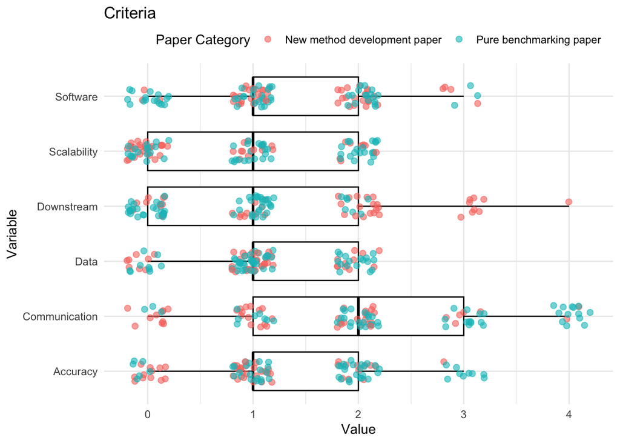

```r
# Create the combined plot with larger size

df_long <- pivot_longer(df_final, cols = c("Software", "Communication", "Downstream", "Data", "Scalability", "Accuracy"), names_to = "Variable", values_to = "Value")

combined_plot <- ggplot(df_long, aes(x = Value, y = Variable)) +
  geom_boxplot(color = "black", width = 0.7) +
  geom_point(aes(color = factor(PaperCategory)), position = position_jitter(width = 0.2, height = 0.2), alpha = 0.6, size = 2) +
  xlab("Value") +
  ylab("Variable") +
  ggtitle("Criteria ") +
  theme_minimal() +

  theme(
    legend.position = "top",
    legend.justification = "right",
    legend.box.just = "right",
    legend.margin = margin(t = 0, r = 10, b = 0, l = 0),
    legend.background = element_rect(fill = "transparent", color = NA)
  ) +
  labs(color = "Paper Category")  # Rename the legend title

# Display the combined plot
combined_plot
```

## Relative Impact of Criterias on Citation Count

### Stepwise negative binomial regression model

#### Model

Furthermore, in the case of citation count, it is plausible that the presence of an intercept in the model may not be meaningful or necessary. The intercept term represents the expected citation count when all the independent variables (`Software`, `Communication`, `Downstream`, `Data`, `Scalability`, `Accuracy`, `Methods compared`, and `Datasets`) are zero. In the context of citation count, it is unlikely that a paper with zero values for all the predictors would have any citations. By excluding the intercept, the regression model is specifically focused on examining the relationship between the independent variables and citation count, without assuming a non-zero baseline level of citations.

```r
# Remove missing values from the dataset
complete_data <- na.omit(df_final)

# Fit a full linear regression model with complete data
full_model <- glm.nb(CitationCount ~   `Methods compared` + Software + Communication + Downstream + Data +
                  Scalability + Accuracy + `Number of experimental datasets` + `Number of synthetic datasets` +
                  impact_factor + Datasets + Tuning + Criteria - 1, data = complete_data, link = log)

# Perform stepwise regression on the full model
step_model <- step(full_model, direction = "backward")
```

```
## Start:  AIC=855.56
## CitationCount ~ `Methods compared` + Software + Communication +
##     Downstream + Data + Scalability + Accuracy + `Number of experimental datasets` +
##     `Number of synthetic datasets` + impact_factor + Datasets +
##     Tuning + Criteria - 1
##
##
## Step:  AIC=855.56
## CitationCount ~ `Methods compared` + Software + Communication +
##     Downstream + Data + Scalability + Accuracy + `Number of experimental datasets` +
##     `Number of synthetic datasets` + impact_factor + Datasets +
##     Tuning - 1
##
##
## Step:  AIC=855.56
## CitationCount ~ `Methods compared` + Software + Communication +
##     Downstream + Data + Scalability + Accuracy + `Number of experimental datasets` +
##     `Number of synthetic datasets` + impact_factor + Tuning -
##     1
##
##                                     Df Deviance     AIC
## - Communication                      1   100.14  853.56
## - `Number of experimental datasets`  1   100.15  853.57
## - Accuracy                           1   100.19  853.61
## - Data                               1   100.72  854.14
## - impact_factor                      1   100.95  854.37
## <none>                                   100.14  855.56
## - Software                           1   102.44  855.86
## - Scalability                        1   102.65  856.07
## - `Number of synthetic datasets`     1   102.68  856.10
## - Downstream                         1   109.27  862.69
## - `Methods compared`                 1   114.49  867.91
## - Tuning                             2   855.36 1606.78
##
## Step:  AIC=853.56
## CitationCount ~ `Methods compared` + Software + Downstream +
##     Data + Scalability + Accuracy + `Number of experimental datasets` +
##     `Number of synthetic datasets` + impact_factor + Tuning -
##     1
##
```

[output cut: 58 more lines]

```
## - `Methods compared`              1   117.26  863.34
## - Tuning                          2  1310.79 2054.87
##
## Step:  AIC=846.99
## CitationCount ~ `Methods compared` + Software + Downstream +
##     Scalability + `Number of synthetic datasets` + Tuning - 1
##
##                                  Df Deviance     AIC
## <none>                                100.23  846.99
## - `Number of synthetic datasets`  1   102.93  847.69
## - Software                        1   103.04  847.80
## - Scalability                     1   104.16  848.92
## - Downstream                      1   112.50  857.25
## - `Methods compared`              1   116.84  861.60
## - Tuning                          2  1385.69 2128.45
```

```r
tab_model(step_model)
```

|  | CitationCount |  |  |
| --- | --- | --- | --- |
| Predictors | Incidence Rate Ratios | CI | p |
| Methods compared | 1.03 | 1.01 – 1.04 | **<0.001** |
| Software | 1.07 | 0.99 – 1.16 | 0.088 |
| Downstream | 1.14 | 1.06 – 1.22 | **0.001** |
| Scalability | 1.09 | 1.00 – 1.18 | **0.045** |
| Number of synthetic datasets | 1.00 | 1.00 – 1.00 | 0.096 |
| Tuning [Default setting] | 30.72 | 25.45 – 37.12 | **<0.001** |
| Tuning [Parameter tuning] | 31.30 | 24.85 – 39.50 | **<0.001** |
| Observations | 100 |  |  |
| R<sup>2</sup> Nagelkerke | 1.000 |  |  |

#### Assumptions of negative binomial regression model

1. Independence: The observations in the datasets are assumed to be independent of each other

```r
# Check for independence using Durbin-Watson test
dwtest(step_model)
```

```
##
##  Durbin-Watson test
##
## data:  step_model
## DW = 1.9606, p-value = 0.3975
## alternative hypothesis: true autocorrelation is greater than 0
```

The Durbin-Watson test result of 1.9606 with a p-value of 0.3975 suggests no significant positive autocorrelation in the residuals, indicating that the assumption of independence is likely met. Moreover, the dataframe is only filtered to only record of each paper only once, hence this assumption is satisfied.

2. Linearity: The relationship between the response variable and the predictor variables is assumed to be l inear.

In this predicted vs. residuals plot, the points are randomly scattered around zero without any discernible pattern, indicating that the linearity assumption holds

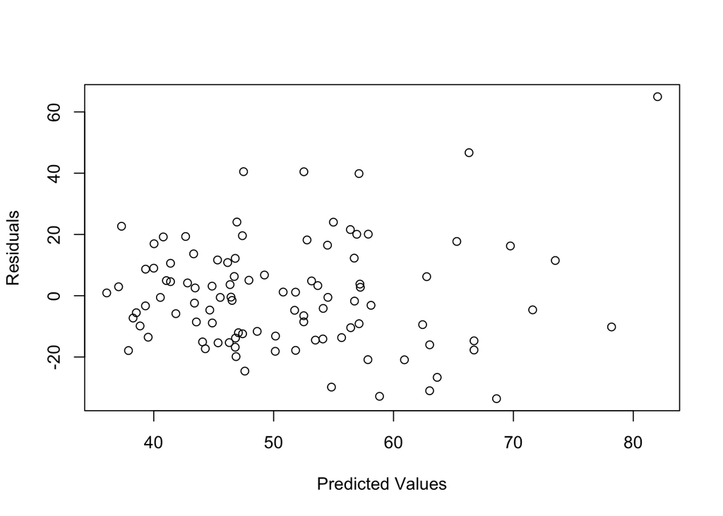

```r
# Assuming you have the fitted model stored in the variable 'model'

# Obtain the predicted values from the model
predicted <- predict(step_model, type = "response")

# Plot observed values against predicted values
plot(predicted, residuals(step_model, type = "response"), xlab = "Predicted Values", ylab = "Residuals")
```

3. Overdispersion: The observed variance of the response variable is greater than its mean

```r
# Check for overdispersion using residual deviance and degrees of freedom
summary(step_model)$deviance / summary(step_model)$df.residual
```

```
## [1] 1.077729
```

The overdispersion score is approximately 1.077729, which suggests that there is a slight degree of overdispersion in the data. This means that the observed data exhibit slightly more variability than what would be expected under the assumed distribution in the model. Hence, the negative bionomial regression model should be applied.

### Linear regression model

Another model explored is linear regression model. The code fits a linear regression model with CitationCount as the dependent variable and several independent variables, including Software, Communication, Downstream, Data, Scalability, Accuracy, Methods compared, Tuning, and impact_factor, using data from the df_final dataset, excluding the intercept term.

```r
model <- lm(CitationCount   ~   Software + Communication + Downstream +Data + Scalability + Accuracy + `Methods compared`+ Tuning + impact_factor  -1  , data = df_final)

# Get the summary of the regression model
tab_model( model)
```

|  | CitationCount |  |  |
| --- | --- | --- | --- |
| Predictors | Estimates | CI | p |
| Software | 3.06 | -1.62 – 7.73 | 0.197 |
| Communication | 0.47 | -2.98 – 3.93 | 0.785 |
| Downstream | 5.54 | 1.04 – 10.04 | **0.016** |
| Data | 1.23 | -4.87 – 7.34 | 0.689 |
| Scalability | 3.99 | -1.08 – 9.06 | 0.121 |
| Accuracy | 0.68 | -4.15 – 5.50 | 0.782 |
| Methods compared | 1.23 | 0.48 – 1.98 | **0.002** |
| Tuning [Default setting] | 22.41 | 8.14 – 36.68 | **0.002** |
| Tuning [Parameter tuning] | 24.48 | 7.42 – 41.53 | **0.005** |
| impact factor | 0.11 | -0.15 – 0.37 | 0.412 |
| Observations | 100 |  |  |
| R<sup>2</sup> / R<sup>2</sup> adjusted | 0.895 / 0.883 |  |  |

The table of the linear regression model presents the estimated coefficients, confidence intervals, and p-values for the predictors. These values can be interpreted as follows:

- Estimated coefficients: The estimated coefficients represent the average change in the response variable `CitationCount` associated with a one-unit increase in the corresponding predictor. For example, a coefficient of 3.06 for the “Software” predictor suggests that, on average, one more subcriteria scored in the “Software” variable is associated with a 3.06 increase in the citation count, holding all other predictors constant.
- Confidence intervals: The confidence intervals provide a range of plausible values for the true effect size of the predictor. It indicates the precision of the estimated coefficient. For instance, a confidence interval of -1.62 to 7.73 for the `Software` predictor suggests that we can be 95% confident that the true effect size lies within this range.
- P-values: The p-values indicate the statistical significance of each predictor. A p-value less than the chosen significance level (usually 0.05) suggests that the predictor is statistically significant. In the model, predictors such as `Downstream`, `Methods compared`, `Tuning [Default setting]`, and `Tuning [Parameter tuning]` have p-values less than 0.05, indicating a significant association with the citation count. On the other hand, predictors with p-values greater than 0.05, such as `Software`, `Communication`, and `Data`, do not show strong evidence of a significant relationship with the outcome.
- The R-squared value for this model is 0.895, indicating that approximately 89.5% of the variability in the citation count can be explained by the predictors included in the model.

1. Linearity: The relationship between the response variable and the predictor variables is assumed to be linear.

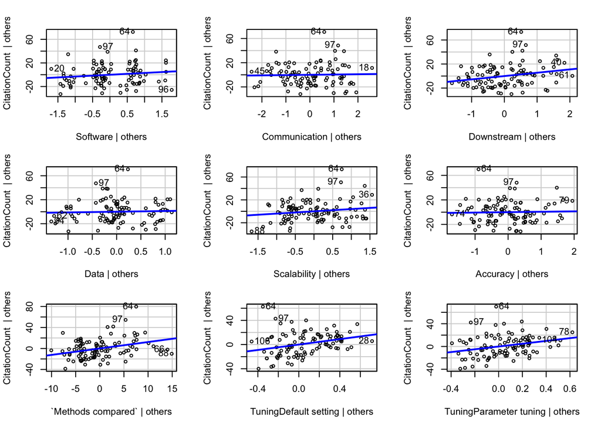

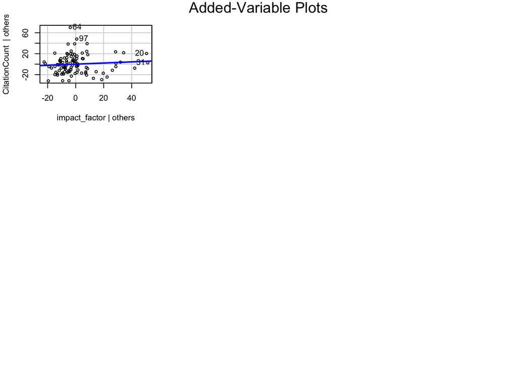

```r
avPlots(model)
```

2. Independence: The observations in the datasets are assumed to be independent of each other

Since the dataframe is filtered out to only contain information about unique papers, this assumption is met.

3. Normality:The residuals of the model are normally distributed

In the Q-Q plot below, most of data points follows the line. Hence, this assumption is satisfied.

4. Homoscedasticity: The variance of the residuals is constant across all levels of the predictor variables.

A look at the residuals vs fitted plot shows a random scatter of points around a horizontal line with a roughly constant spread, indicating that the linearity assumption and constant variance assumption (homoscedasticity) are satisfied.

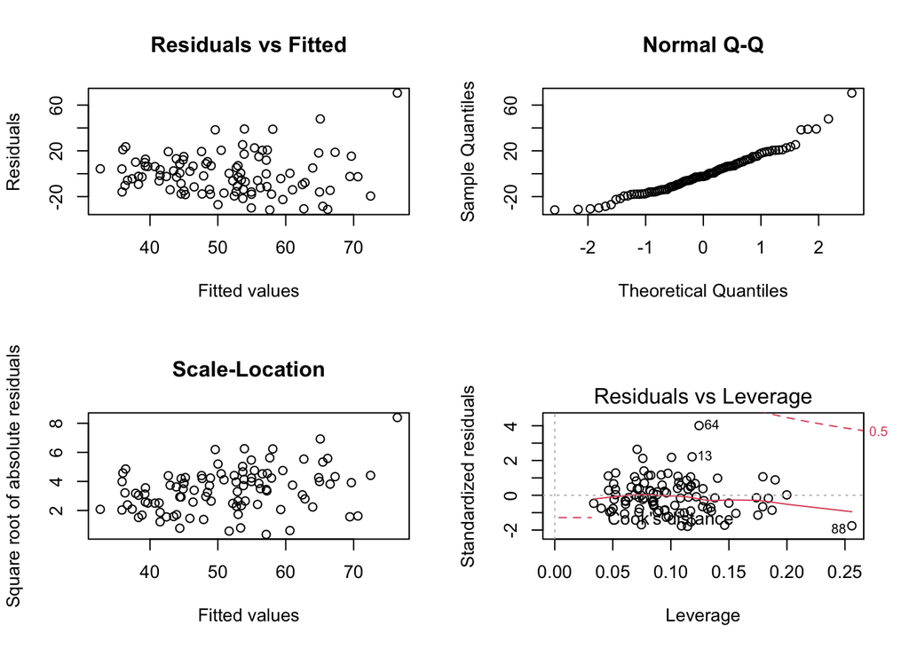

```r
# Diagnostic plot for model
par(mfrow = c(2, 2))  # Set the plot layout to 2x2

# Residuals vs Fitted plot
plot(model$fitted.values, model$residuals,
     xlab = "Fitted values", ylab = "Residuals",
     main = "Residuals vs Fitted")

# Normal Q-Q plot
qqnorm(model$residuals, main = "Normal Q-Q")

# Scale-Location plot
sqrt_abs_residuals <- sqrt(abs(model$residuals))
plot(model$fitted.values, sqrt_abs_residuals,
     xlab = "Fitted values", ylab = "Square root of absolute residuals",
     main = "Scale-Location")

# Residuals vs Leverage plot
plot(model, which = 5)
```

# Summary

## Limitations

One limitation of the model is its disregard for the publication date of papers when predicting the citation count. It is plausible that papers published for a longer duration accumulate more citations. However, acquiring publication dates using `rentrez` library result in a significant number of missing values in the publication date column. Nonetheless, if this information is available, calculating the average citation count per year becomes feasible. As the response variable, considering the average citation count per year provides a meaningful metric that captures the long-term impact and influence of papers, taking into account their publication dates. By incorporating this information into the model, we can gain insights into the temporal trends and patterns of citation accumulation, allowing for a more comprehensive analysis of the factors driving citation counts in the field.

Moreover, one limitation of the scoring system is that it assigns equal weights to each subcriteria within a criterion. This may not always accurately reflect the relative importance or impact of each subcriteria. Some subcriteria may have a greater influence on the overall evaluation, but this is not captured in the equal weighting approach. Incorporating a weighting scheme based on the perceived importance or relevance of each subcriteria could provide a more nuanced and accurate assessment of the papers’ quality and contribution.

# Appendix

```r
library(data.table)
library(DT)
library(rentrez)
library(readr)
library(tidyverse)
library(sjPlot)
library(lme4)
library(lubridate)
library(bench)
library(patchwork)
library(stats)     # Required for linear regression (lm) function
library(stats4)    # Required for linear regression (lm) function
library(dplyr)     # Required for data manipulation and transformation
library(matrixStats)  # Required for matrix operations
library(knitr)
library(kableExtra)
library(car)
library(lmtest)
library(MASS)
```

## Data Cleaning

In this project, the benchmark survey response dataset was preprocessed to ensure data quality and consistency.

1. Eliminate columns with a high percentage of missing values were eliminated
2. Drop unnecessary columns containing irrelevant information for interest

   ```r
   df <- read_csv("benchmark_survey_response_anonymous.csv")
   # Narow down dataframe by eliminating columns where over half of records are 'NA' values
   na_counts <- colSums(is.na(df))
   num_rows <- nrow(df)
   columns_to_drop <- names(na_counts[na_counts > 0.5*num_rows])
   df <- df[, !(names(df) %in% columns_to_drop)]
   df <- df[, -c(1,3)]
   ```

3. Fetch citation count and publication date for each paper

```r
# Function to fetch citation count
get_citation_count <- function(pmid) {
  record <- tryCatch(
    entrez_summary(db = "pubmed", id = pmid),
    error = function(e) NA
  )
  if (!is.na(record) && !is.null(record$pmcrefcount)) {
    return(record$pmcrefcount)
  } else {
    return(NA)
  }
}

# Function to fetch publication date
get_publication_date <- function(pmid) {
  record <- tryCatch(
    entrez_summary(db = "pubmed", id = pmid),
    error = function(e) NA
  )
  if (!is.na(record) && !is.null(record$pubdate)) {
    return(record$pubdate)
  } else {
    return(NA)
  }
}

# Add citation count column
df$CitationCount <- sapply(df$PMID, get_citation_count)

# Add publication date column
df$PublicationDate <- sapply(df$PMID, get_publication_date)
```

4. Save cleaned data into CSV file for further analysis

```r
# Write the DataFrame to CSV
write.csv(df, file = "data.csv", row.names = TRUE)
```

5. Grouping columns within the same criteria together

```r
df_final<- read_csv("data.csv")

df_final <-
  df_final %>%
  mutate_at(vars("Diversity of experimental data","Diversity of synthetic datasets", "Number of experimental datasets", "Number of synthetic datasets" ), ~replace(., is.na(.), 0))

df_final$Software <- as.integer(df_final$Website == "Yes") + as.integer(df_final$"Data availability" == "Yes") + as.integer(df_final$"Package availability" == "Yes")

df_final$Communication <- as.integer(df_final$Recommendation == "Yes") + as.integer(df_final$Applicability == "Yes") + as.integer(df_final$"Trade-offs" == "Yes") + as.integer(df_final$"Future directions" == "Yes")

df_final$Downstream <- as.integer(df_final$"Downstream analysis" == "Yes") + as.integer(df_final$"Prior knowledge" == "Yes") + as.integer(df_final$"Discovery?" == "Yes") + as.integer(df_final$"Wet lab validation" == "Yes")

df_final$Data <- as.integer(df_final$"Diversity of experimental data" == "Yes") + as.integer(df_final$ "Diversity of synthetic datasets" == "Yes")

df_final$Scalability <- as.integer(df_final$"Speed measured?" == "Yes") + as.integer(df_final$"Memory measured" == "Yes")

df_final$Accuracy <- as.integer(df_final$"Selection criteria" == "Yes") + as.integer(df_final$"Variability of score" == "Yes") +  as.integer(df_final$"Overall comparison" == "Yes")

df_final <- df_final[!is.na(df_final$CitationCount), ]
colnames(df_final)[colnames(df_final) == "Paper category"] <- "PaperCategory"

df_final$Datasets <- df_final$`Number of experimental datasets` + df_final$`Number of synthetic datasets`

df_final <- df_final[, c("PMID", "PaperCategory", "Methods compared", "Software", "Communication", "Downstream", "Data", "Scalability", "Accuracy","Number of experimental datasets", "Number of synthetic datasets", "impact_factor","CitationCount", "Datasets")]

#df_final$publication_date <- ymd(df_final$PublicationDate)
```

# Reflection

One of the lessons I learned from this project is the importance of grouping or transforming large datasets in a meaningful way to extract valuable insights. By organizing the data into relevant categories or applying suitable transformations, we can uncover patterns and make data more manageable for analysis. This process not only helps in gaining a deeper understanding of the data but also facilitates the extraction of actionable information from complex datasets.

The most striking observation I made from the consulting projects this semester is the value of asking thorough and comprehensive questions to gather as much information as possible. I realized that asking detailed and targeted questions can help a consultant to gain a deeper understanding of the clients’ needs, challenges, and expectations. This enabled to provide more tailored and effective solutions to meet their specific requirements. Additionally, asking probing questions helped uncover hidden insights and potential issues that may have been overlooked initially. It highlighted the importance of active listening and curiosity in consulting engagements, as well as the role of comprehensive questioning in uncovering valuable information and delivering high-quality outcomes for clients.